# Repro 2 – Better than Reproducibility

Jeffrey A. Walker

2023-11-22

# Part 1 – Fig 2B-C Glycerol contributes to tuberculosis susceptibility in male mice with type 2 diabetes

The assignment is: Better than reproduce the analysis of the experiment presented in Figs. 2B and 2C of the article

Source article: [Martinez, Nuria, et al. “Glycerol contributes to tuberculosis susceptibility in male mice with type 2 diabetes.” Nature Communications 14.1 (2023): 5840.](https://www.nature.com/articles/s41467-023-41519-9)

dataset: Martinez-Glycerol-fig2.xlsx

You need to 1) import the data, 2) analyze the data **for figures 2B and 2c**, and 3) report the results following the example in [Section 10.1.1](https://www.middleprofessor.com/files/applied-biostatistics_bookdown/_book/oneway#oneway-example1)

**From the abstract**: “Here we show that male mice receiving a high-fat diet and streptozotocin to model type 2 diabetes, have higher mortality, more lung pathology, and higher bacterial burden following *Mycobacterium tuberculosis* infection compared to mice treated with streptozotocin or high-fat diet alone.”

**Results leading up to the experiment in Fig 2**: “HFD-STZ mice exhibit hypoinsulinemia, insulin resistance, hyperglycemia, and dyslipidemia” – basically the authors showed that HFD + STZ creates a a type 2 diabetes (T2D) like physiology. The goal is to create a T2D model to see if this T2D physiology is more vulnerable to tuberculosis markers from *Mycobacterium tuberculosis* infection.

**Motivating question**: “We hypothesized that the combined perturbation of glucose and lipid metabolism characteristic of type 2 DM, has additive or synergistic effects on TB severity as reported with microvascular complications.”

**Experimental Model** Mice infected with *Mycobacterium tuberculosis* (Mtb)

**Author’s reported result** “The infected HFD-STZ mice also had the highest lung CFU and lesion area at 8 weeks p.i. (Fig. 2b, c).”

**Author’s conclusion** 1. “Overall, the TB susceptibility phenotype and immune function perturbations in HFD-STZ type 2 DM model identified an additive or synergistic detrimental effect of hyperglyce- mia and altered lipid metabolism on host defense, reminiscent of their combined effect on the vascular complications of type 2 DM” 2. “We speculated that the dyslipidemia associated with type 2 DM could further exacerbate the immunopathy caused by hyperglycemia alone. That notion was reinforced by initial evidence from the present study showing that these combined metabolic perturbations synergistically increased TB severity (Fig. 2)”

**What is Synergy** – Google the definition. Also look at the Factorial chapter in the textbook where I discuss synergism.

**Response variable**: 1. Fig 2b: *cfu* – bacterial colony forming units 2. Fig 2c: *percent_lesion* – percent of lung area with TB lesions.

**Factor variables**

1. Factor 1: *diet* with levels = (“CD”, “HFD”)
- CD – control (chow) diet.
- HFD – high fat diet
2. Factor 2: *stz* with levels = (“Veh”, “STZ”)
- Veh – “vehicle”
- STZ – Streptozotocin

**Streptozotocin** is a metabolite of the soil microbe *Streptomyces achromogenes* that damages DNA and is toxic to cells. Remarkably (to me) it is similar enough to glucose that it is transported by GLUT2 (but apparently less so by other GLUTs), which is especially common in pancreatic beta cells, the cells that make insulin. Therefore, STZ kills beta cells and creates diabetes. Because most cell types express little or no GLUT2, it is much less toxic to other cell types. See the [wikipedia article for more information](https://en.wikipedia.org/wiki/Streptozotocin).

Groups:

1. CD/Veh – the negative control giving the background condition
2. HFD/Veh – A positive control on HFD.
3. CD/STZ – the positive control on STZ.
4. HFD/STZ – the focal treatment.

Contrasts of interest: You do this!

Assignment:

1. Write out all contrasts and which are of interest and which are not, and why for both.
2. Do your own statistics! Do better than the authors!
3. Plot the response! Do better than the authors!
4. Write a short statement communicating the inference – Do better than the authors!
5. Write a short comment on the author’s conclusion that the results in Fig 2 show that “these combined metabolic perturbations synergistically increased TB severity (Fig. 2)”

```r
data_from <- "Glycerol contributes to tuberculosis susceptibility in male mice with type 2 diabetes"
file_name <- "Martinez-Glycerol-fig2.xlsx"
file_path <- here(data_folder, data_from, file_name)
fig2 <- read_excel(file_path,
                    sheet = "figure 2",
                    range = "A1:J32") |>
  data.table()
# create factors with meaningful order of levels
fig2[, diet := factor(diet, levels = c("CD", "HFD"))]
fig2[, stz := factor(stz, levels = c("Veh", "STZ"))]
```

## 2. Do your own statistics! Do better than the authors!

We can do better using a factorial model! The authors used “one-way ANOVA” meaning they “flattened” the 2 x 2 design (two factors each with two groups) into a 1 x 4 (one factor with four groups) model. Tsk-tsk. In the 2 x 2 factorial model, the interaction effect is automatic, because it’s a coefficient of the model. In a flattened analysis, we can still compute the interaction using the manual planned contrasts but GUI packages like Graphpad Prism will not give you the interaction statistics because the software is unaware that it’s a 2 x 2 design if you input it as a 1 x 4 flattened model!

Note that the authors explicitly argued for a synergistic effect. Synergy means “more than the sum of the parts” This is of course a positive interaction! To measure synergy you have to measure the interaction effect!

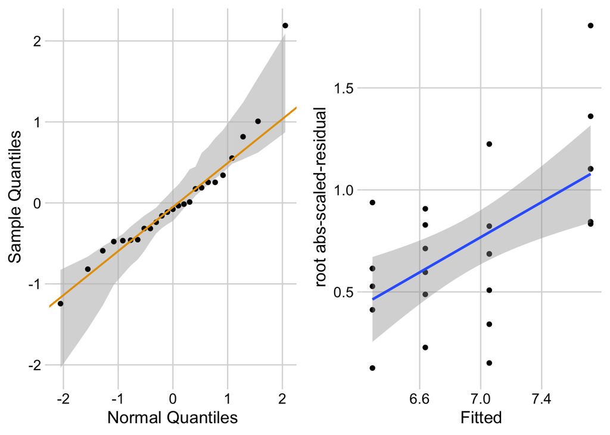

```r
fig2b_m1 <- lm(cfu ~ diet * stz, data = fig2)
ggcheck_the_model(fig2b_m1)
```

CFU is a count so we should think about a glm model. The qq plot suggests the sample is on the edge of what we’d expect from a normal distribution. The spread-level plot suggests heterogeneity. Neither are excessive and, since we have not done glm yet, we will stay with lm model.

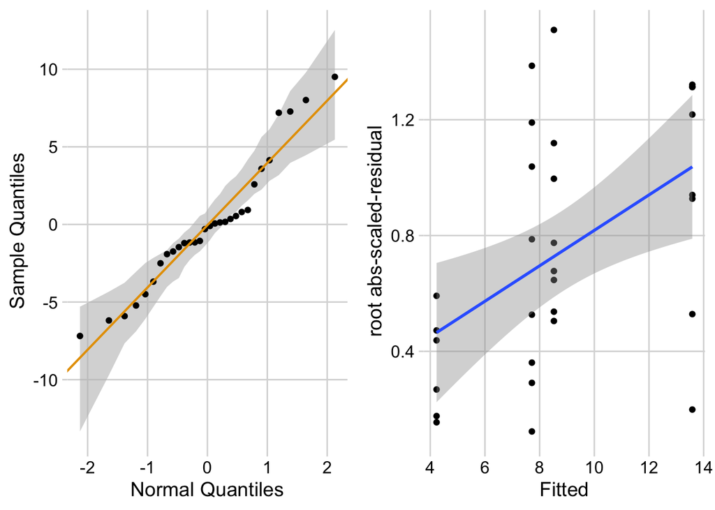

```r
fig2c_m1 <- lm(percent_lesion ~ diet * stz, data = fig2)
ggcheck_the_model(fig2c_m1)
```

QQ plot again has excess small values in the middle but otherwise okay. Spread level plot is on the edge of heterogeniety.

```r
control = c(1,0,0,0)
hfd = c(0,1,0,0)
stz = c(0,0,1,0)
both = c(0,0,0,1)
planned <- list(
  "CD: STZ - Veh" = stz - control,
  "HFD: STZ - Veh" = both - hfd,
  "Ixn" = (both - hfd) - (stz - control) # STZ - No STZ with and without HFD
)

fig2b_emm <- emmeans(fig2b_m1, specs = c("diet", "stz"))
fig2b_planned <- contrast(fig2b_emm,
                          method = planned,
                          adjust = "none") |>
  summary(infer = TRUE) |>
  data.table()

# for this I want to show both - control, but also want to report all contrasts
fig2b_pairs <- contrast(fig2b_emm,
                       method = "revpairwise",
                       adjust = "none") |>
  summary(infer = TRUE)
```

```r
fig2c_emm <- emmeans(fig2c_m1, specs = c("diet", "stz"))
fig2c_planned <- contrast(fig2c_emm,
                          method = planned,
                          adjust = "none") |>
  summary(infer = TRUE) |>
  data.table()


# this is for the supplement
fig2c_pairs <- contrast(fig2c_emm,
                       method = "revpairwise",
                       adjust = "none") |>
  summary(infer = TRUE)
```

For synergy, we want to see 1. effect of each single treatment vs. control 2. effect of stz with and without HFD 3. the interaction

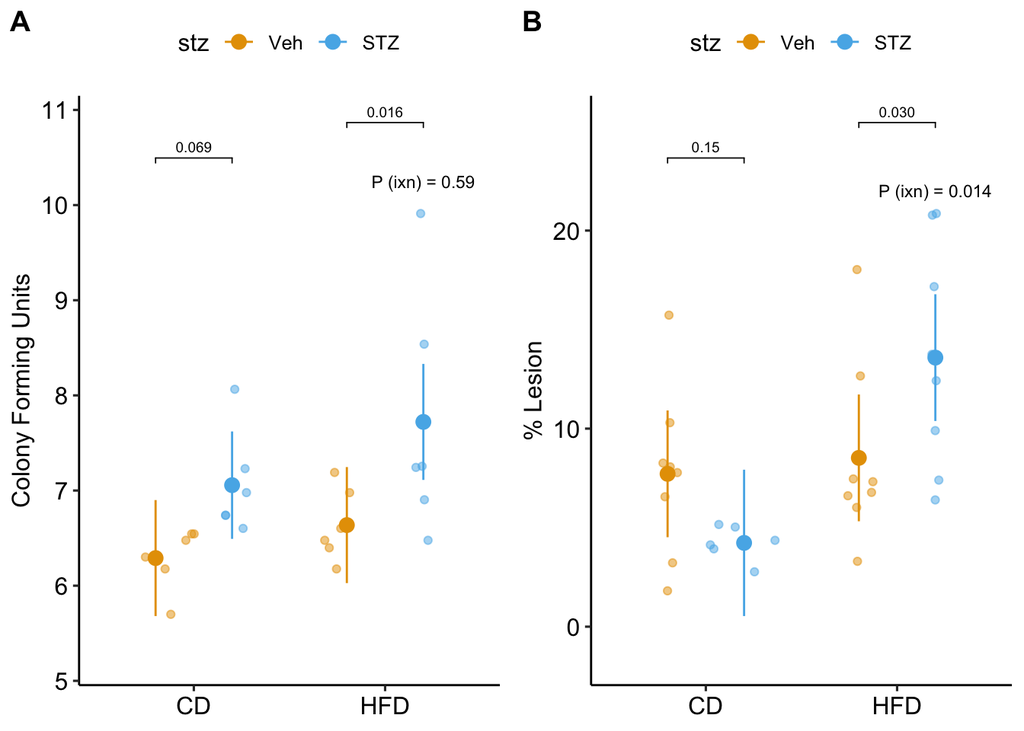

```r
# want to show p-values of stz effect with and without HFD
inc <- c(2, 5) # rows of pairs table
gg1 <- ggplot_the_response(fig2b_m1, fig2b_emm, fig2b_pairs[inc,],
                    y_label = "Colony Forming Units") +
  annotate(geom = "text",
           x = 2.2, # CD and HFD have x coordinates of 1 and 2
           y = 10.25, # this is the y coordinate on this graph
           label = paste("P (ixn) =", round(fig2b_planned[contrast == "Ixn", p.value], 2)),
           color = "black",
           size = 3) +
  NULL
gg2 <- ggplot_the_response(fig2c_m1, fig2c_emm, fig2c_pairs[inc,],
                    y_label = "% Lesion") +
  annotate(geom = "text",
           x = 2.2, # CD and HFD have x coordinates of 1 and 2
           y = 22, # this is the y coordinate on this graph
           label = paste("P (ixn) =", round(fig2c_planned[contrast == "Ixn", p.value], 3)),
           color = "black",
           size = 3) +
  NULL
plot_grid(gg1, gg2, labels = "AUTO")
```

Notes

1. this report doesn’t use the word “significant”!
2. I like how this report includes the CIs for the direction and magnitude of the effect without either the mean or the p-value…but these are in the plot so it would be wordy and redundant to include in the text.

# Part 2 – Fig 5k from CD300ld on neutrophils is required for tumour-driven immune suppression

The assignment is: Better than reproduce the analysis of the experiment presented in Figs. 5k of the article

Source article: [Wang, Chaoxiong, et al. “CD300ld on neutrophils is required for tumour-driven immune suppression.” Nature (2023): 1-10.](https://www.nature.com/articles/s41586-023-06511-9)

dataset: Wang-CD300ld-fig5k.xlsx

You need to 1) import the data, 2) analyze the data **for figure 5k**, and 3) report the results following the example in [Section 10.1.1](https://www.middleprofessor.com/files/applied-biostatistics_bookdown/_book/oneway#oneway-example1)

**From the abstract**: “Here, we performed an in vivo CRISPR–Cas9 screen in a tumour mouse model and identified CD300ld as a top candidate of tumour-favouring receptors…Blocking CD300ld activity inhibits tumour development and has synergistic effects with anti-PD1”

**Motivating question**: “PD1 inhibits the activation of T cells and CD300ld is essential for PMN-MDSCs to suppress T cells, suggesting that dual blockage of PD1 and CD300ld may exhibit stronger anti-tumour efficacy.”

**Experimental Model** “To test this, we treated wild-type and Cd300ld-KO B16-F10 tumour-bearing mice with anti-PD1 at day 7 post-tumour inoculation.”

1. Cd300ld-KO are conditional knockouts using the cre-lox system.
2. B16-F10 is a line of melanoma cells. These were injected into the mice

**Author’s reported result** “Anti-PD1 treatment resulted in significant tumour inhibition in both wild-type and Cd300ld-KO mice and substantially increased mice survival (Fig. 5j–l), demonstrating that the anti-PD1 and CD300ld knockout act synergistically.”

**What is Synergy** – Google the definition. Also look at the Factorial chapter in the textbook where I discuss synergism.

**Response variable**:

1. Fig 5k: *day_19* – For each mouse, the tumor volume is given over a 19 day period. **Analyze only the day_19 data**.

**Factor variables**

1. Factor 1: *genotype* with levels = (“WT”, “KO”)
- WT – Cd300ldfl/fl - these are mice with the gene construct but the gene has not been knocked out.
- KO – Cd300ld-KO
2. Factor 2: *pd1* with levels = (“Isotype”, “anti-PD1”) – “The 2A3 monoclonal antibody reacts with trinitrophenol. Because trinitrophenol is not expressed by mammals this antibody is ideal for use as an isotype-matched control”
- Isotype – intraperitoneal injection of isotype (10 mg kg−1, 2A3, Bioxcell) - a monoclonal antibody that blocks pd1 or pd-l1
- anti-PD1 – intraperitoneal injection of anti-PD1 (10 mg kg−1, RMP1-14, Bioxcell) - a monoclonal antibody that blocks pd1 or pd-l1

Notes

See the [wikipedia article for more information](https://en.wikipedia.org/wiki/Streptozotocin).

Groups:

1. WT/Isotype – the negative control giving the background tumor volume
2. KO/Isotype – A positive control on KO
3. WT/anti-PD1 – the positive control on anti-pd1
4. KO/anti-PD1 – the focal treatment.

Contrasts of interest: You do this!

Assignment:

1. Write out all contrasts and which are of interest and which are not, and why for both.
2. Do your own statistics! Do better than the authors!
3. Plot the response! Do better than the authors! - Note that you won’t be plotting the time series; only the data at day 19.
4. Write a short statement communicating the inference – Do better than the authors!
5. Write a short comment on the author’s conclusion that the results in Fig 5k show that “the anti-PD1 and CD300ld knockout act synergistically”

## 2. Do your own statistics! Do better than the authors!

(same as what I wrote above). We can do better using a factorial model! The authors used “one-way ANOVA” meaning they “flattened” the 2 x 2 design (two factors each with two groups) into a 1 x 4 (one factor with four groups) model. Tsk-tsk. In the 2 x 2 factorial model, the interaction effect is automatic, because it’s a coefficient of the model. In a flattened analysis, we can still compute the interaction using the manual planned contrasts but GUI packages like Graphpad Prism will not give you the interaction statistics because the software is unaware that it’s a 2 x 2 design if you input it as a 1 x 4 flattened model!

Note that the authors explicitly argued for a synergistic effect. Synergy means “more than the sum of the parts” This is of course a positive interaction! To measure synergy you have to measure the interaction effect!

```r
data_from <- "CD300ld on neutrophils is required for tumour-driven immune suppression"
file_name <- "Wang-CD300ld-fig5k.xlsx"
file_path <- here(data_folder, data_from, file_name)
fig5k <- read_excel(file_path,
                    sheet = "fig 5k",
                    range = "A1:I54") |>
  data.table()
# create factors with levels in meaningful order for models/plots
fig5k[, genotype := factor(genotype, levels = c("WT", "KO"))]
fig5k[, pd1 := factor(pd1, levels = c("Isotype", "anti-PD1"))]
```

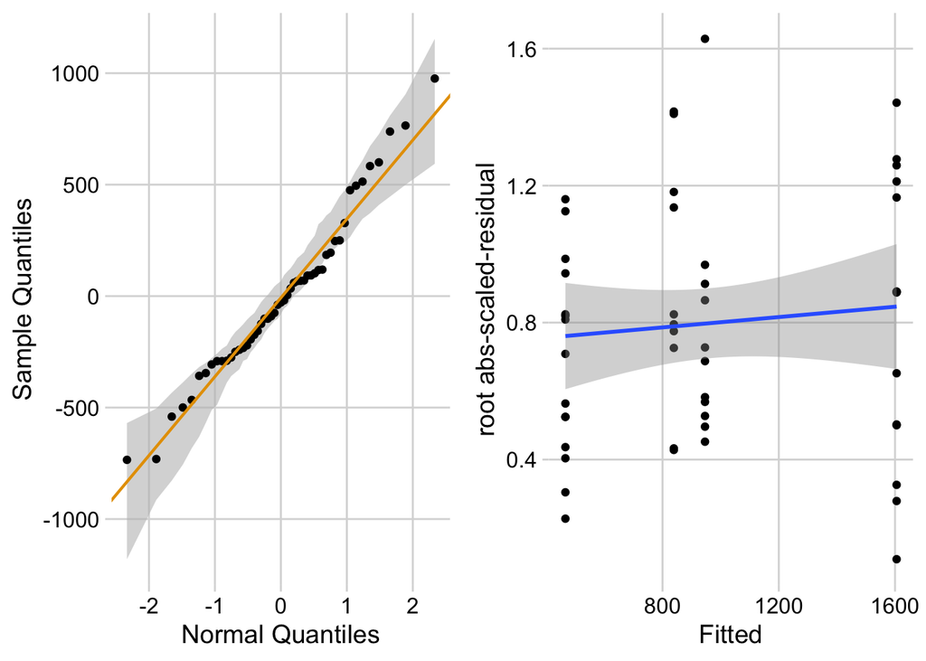

```r
fig5k_m1 <- lm(day_19 ~ genotype * pd1, data = fig5k)
ggcheck_the_model(fig5k_m1)
```

The data look like a sample from the same normal distribution

```r
control = c(1,0,0,0)
ko = c(0,1,0,0)
apd1 = c(0,0,1,0)
both = c(0,0,0,1)
planned <- list(
  "WT: ANTI_PD1 - Isotype" = apd1 - control,
  "KO: ANTI_PD1 - Isotype" = both - ko,
  "Ixn" = (both - ko) - (apd1 - control) # apd1 - No apd1 with and without KO
)

fig5k_emm <- emmeans(fig5k_m1, specs = c("genotype", "pd1"))
fig5k_planned <- contrast(fig5k_emm,
                          method = planned,
                          adjust = "none") |>
  summary(infer = TRUE) |>
  data.table()

# for this I want to show both - control, but also want to report all contrasts
fig5k_pairs <- contrast(fig5k_emm,
                       method = "revpairwise",
                       adjust = "none") |>
  summary(infer = TRUE)
```

```r
fig5k_planned |>
  kable(digits = c(1,1,1,1,1,1,1,6)) |>
  kable_styling()
```

| contrast | estimate | SE | df | lower.CL | upper.CL | t.ratio | p.value |
| --- | --- | --- | --- | --- | --- | --- | --- |
| WT: ANTI_PD1 - Isotype | -766.6 | 152.9 | 47 | -1074.2 | -459.1 | -5.0 | 0.000008 |
| KO: ANTI_PD1 - Isotype | -480.3 | 150.6 | 47 | -783.3 | -177.3 | -3.2 | 0.002540 |
| Ixn | 286.3 | 214.6 | 47 | -145.5 | 718.0 | 1.3 | 0.188641 |

The estimated interaction effect is in the opposite direction of that expected for synergy.

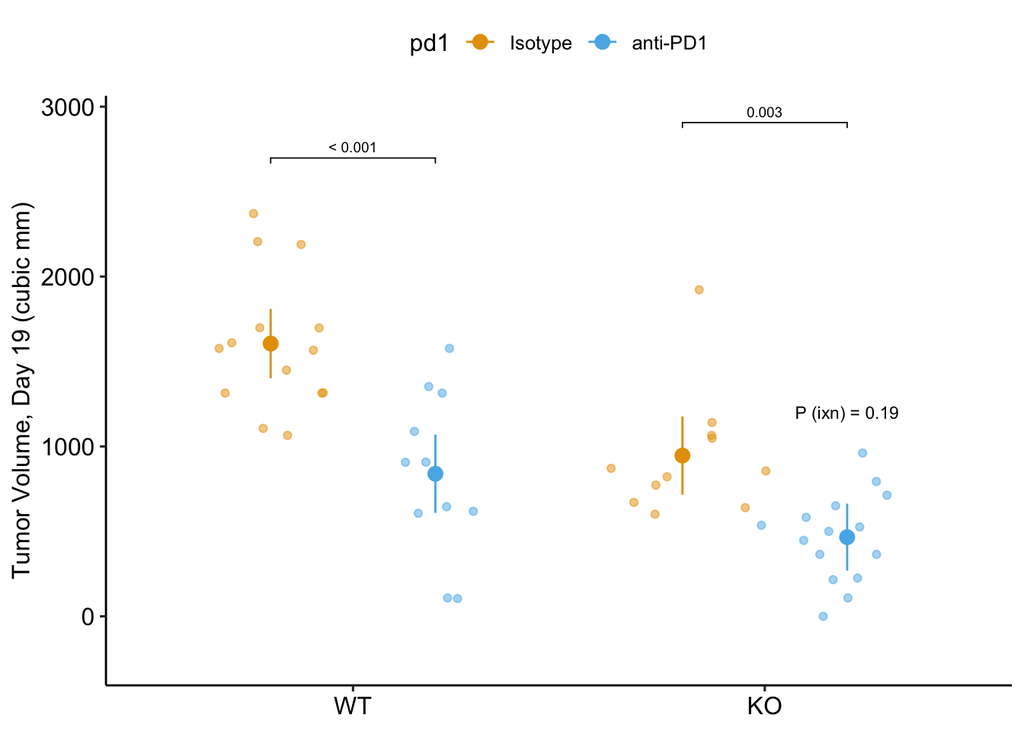

```r
# want to show p-values of stz effect with and without HFD
inc <- c(2, 5) # rows of pairs table
gg1 <- ggplot_the_response(fig5k_m1, fig5k_emm, fig5k_pairs[inc,],
                    y_label = "Tumor Volume, Day 19 (cubic mm)") +
  annotate(geom = "text",
           x = 2.2, # CD and HFD have x coordinates of 1 and 2
           y = 1200, # this is the y coordinate on this graph
           label = paste("P (ixn) =", round(fig5k_planned[contrast == "Ixn", p.value], 2)),
           color = "black",
           size = 3) +
  NULL
gg1
```

Author’s report: Anti-PD1 treatment resulted in significant tumour inhibition in both wild-type and Cd300ld-KO mice and substantially increased mice survival (Fig. 5j–l), demonstrating that the anti-PD1 and CD300ld knockout act synergistically.

Better than Author’s report: Anti-PD1 treatment resulted in [delete signficant!] tumour inhibition in both wild-type and Cd300ld-KO mice and substantially increased mice survival (Fig. 5j–l). The estimated Cd300ld-KO / Anti-PD1 interaction is small and in the opposite direction of that expected of synergy between the two treatments.

# Mo’ learning – Interactions are dependent on distribution or scale! ha ha ha ha ha ha!

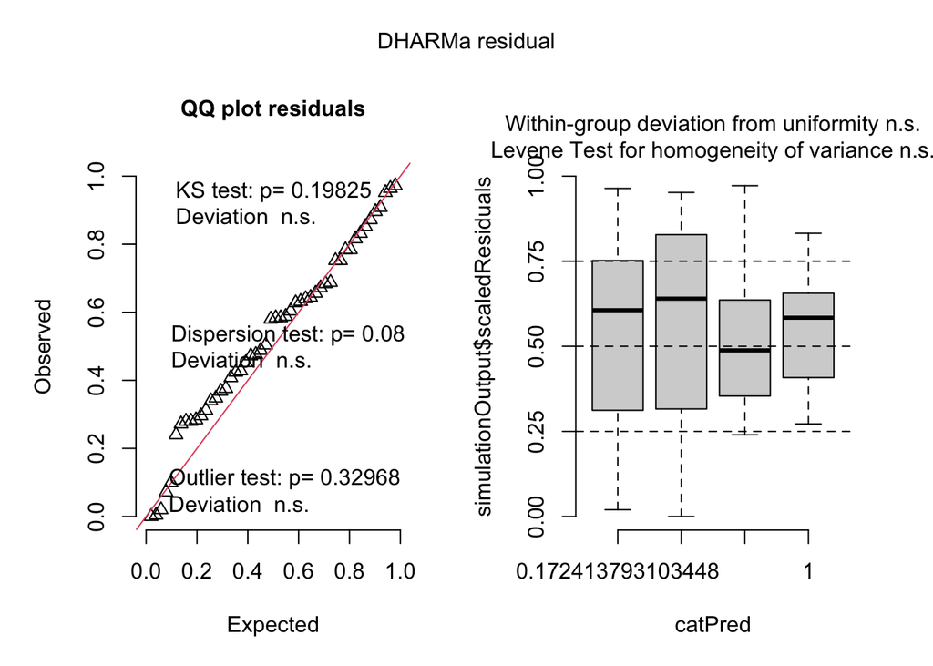

```r
fig5k_m2 <- glm(day_19 ~ genotype * pd1,
                family = Gamma(link = "log"),
                data = fig5k[day_19 != 0])

fig5k_m2_check <- simulateResiduals(fig5k_m2)
plot(fig5k_m2_check)
```

```r
fig5k_emm2 <- emmeans(fig5k_m2, specs = c("genotype", "pd1"), type = "response")
fig5k_planned <- contrast(fig5k_emm2,
                          method = planned,
                          adjust = "none") |>
  summary(infer = TRUE)
fig5k_planned
```

```
##  contrast               ratio     SE df lower.CL upper.CL null t.ratio p.value
##  WT: ANTI_PD1 / Isotype 0.523 0.0908 46    0.368    0.741    1  -3.736  0.0005
##  KO: ANTI_PD1 / Isotype 0.527 0.0917 46    0.372    0.748    1  -3.681  0.0006
##  Ixn                    1.009 0.2481 46    0.616    1.655    1   0.038  0.9695
##
## Confidence level used: 0.95
## Intervals are back-transformed from the log scale
## Tests are performed on the log scale
```

Anti_pd1 is 48% less than Isotopye in both groups but 48% of a bigger number (in WT) is more than 48% of a smaller number (in KO) so on an additive scale there is an ineraction but on a multiplicative scale there isn’t!!!